# QMSS G5072 Homework 4

Wenjun Sun

2019-10-11

# Functions II

### 1. Functions in the dplyr Package

#### a) Longest name

Use the appropriate `map` function to produce a vector of the names of all functions in the dplyr package. Which function has the longest name?

```r
df <- as.data.frame(names(dplyr_functions))
names(df) <- c('name')

df$length <- map_dbl(names(dplyr_functions), nchar)

df %>%
      top_n(1,length) %>%
      kable() %>%
      kable_styling(bootstrap_options = "striped")
```

| name | length |
| --- | --- |
| group_by_drop_default | 21 |

As the above table indicates, the function with the longest name is ‘group_by_drop_default’, which has 21 characters.

#### b) Number of arguments

Use the appropriate `map` function to calculate the number of arguments by function. Present a table of the Top 10 functions with the most arguments. Which function has the most arguments?

```r
df$formals <- map(dplyr_functions, formals)
df$argument <- map(df$formals, names)

df$number <- map_dbl(df$formals, length)

df %>%
      select(name, argument, number) %>%
      arrange(desc(number)) %>%
      top_n(10) %>%
      kable() %>%
      kable_styling(bootstrap_options = "striped")
```

| name | argument | number |
| --- | --- | --- |
| group_rows | c(“kable_input”, “group_label”, “start_row”, “end_row”, “index”, “label_row_css”, “latex_gap_space”, “escape”, “latex_align”, “colnum”, “bold”, “italic”, “hline_before”, “hline_after”, “extra_latex_af… | 16 |
| sql_select | c(“con”, “select”, “from”, “where”, “group_by”, “having”, “order_by”, “limit”, “distinct”, “…”) | 10 |
| nest_join | c(“x”, “y”, “by”, “copy”, “keep”, “name”, “…”) | 7 |
| sql_join | c(“con”, “x”, “y”, “vars”, “type”, “by”, “…”) | 7 |
| all_equal | c(“target”, “current”, “ignore_col_order”, “ignore_row_order”, “convert”, “…”) | 6 |
| compare_tbls2 | c(“tbls_x”, “tbls_y”, “op”, “ref”, “compare”, “…”) | 6 |
| count | c(“x”, “…”, “wt”, “sort”, “name”, “.drop”) | 6 |
| db_create_index | c(“con”, “table”, “columns”, “name”, “unique”, “…”) | 6 |
| db_write_table | c(“con”, “table”, “types”, “values”, “temporary”, “…”) | 6 |
| enexprs | c(“…”, “.named”, “.ignore_empty”, “.unquote_names”, “.homonyms”, “.check_assign”) | 6 |
| enquos | c(“…”, “.named”, “.ignore_empty”, “.unquote_names”, “.homonyms”, “.check_assign”) | 6 |
| ensyms | c(“…”, “.named”, “.ignore_empty”, “.unquote_names”, “.homonyms”, “.check_assign”) | 6 |
| full_join | c(“x”, “y”, “by”, “copy”, “suffix”, “…”) | 6 |
| group_by_at | c(“.tbl”, “.vars”, “.funs”, “…”, “.add”, “.drop”) | 6 |
| group_by_if | c(“.tbl”, “.predicate”, “.funs”, “…”, “.add”, “.drop”) | 6 |
| inner_join | c(“x”, “y”, “by”, “copy”, “suffix”, “…”) | 6 |
| left_join | c(“x”, “y”, “by”, “copy”, “suffix”, “…”) | 6 |
| right_join | c(“x”, “y”, “by”, “copy”, “suffix”, “…”) | 6 |
| sample_frac | c(“tbl”, “size”, “replace”, “weight”, “.env”, “…”) | 6 |
| sample_n | c(“tbl”, “size”, “replace”, “weight”, “.env”, “…”) | 6 |
| sql_semi_join | c(“con”, “x”, “y”, “anti”, “by”, “…”) | 6 |
| src_mysql | c(“dbname”, “host”, “port”, “username”, “password”, “…”) | 6 |
| src_postgres | c(“dbname”, “host”, “port”, “user”, “password”, “…”) | 6 |

Please note that, because there are ties in Top 10 when ranking functions by the number of arguments, so the output of table is longer than 10 rows, but I think it’s fair to include ties.

#### c) Most common argument

Which function arguments are the top 5 most common. Briefly explain what the most common argument does?

```r
all_argument <- unlist(df$argument, use.names = FALSE)

df_argument <- as.data.frame(table(all_argument))

df_argument %>%
                arrange(desc(Freq)) %>%
                top_n(5) %>%
                kable() %>%
                kable_styling(bootstrap_options = "striped")
```

| all_argument | Freq |
| --- | --- |
| … | 150 |
| x | 83 |
| .tbl | 38 |
| .data | 32 |
| .funs | 27 |

No surprisingly, ‘…’ appears to be the most comman arguments of all functions in dplyr(, if it is considered an argument at all).

What ‘…’ does is, when the creator of the function was not sure about how many parameters/arguments would there be in the function, he/she would use ‘…’ to indicate an arbitrary length of parameters/arguments, in order to allow users to decide how many arguments to put there. Here is an example:

```r
example <- function(a, b, ...) {
  sum(a, b, ...)
}
```

```r
example(1,2,3)
```

```
## [1] 6
```

```r
example(1,2,3,4)
```

```
## [1] 10
```

In this case, no matter how many numbers a user put into the function, he/she won’t break the function.

### 2. Infant Mortality and GPD per Capita

For this exercise, we will use data from the World Bank to explore the relationship between infant mortality (`infmort`) and GPD per capita (`gdpcap`) over time (`year`).

#### a) Highest and lowest infant mortality rates in 2018

Use the [`WDI` package](https://cran.r-project.org/web/packages/WDI/WDI.pdf) to obtain country-year data on infant mortality and GDP per capita from the World Bank database.

The indicator short names in the World Development Indicators are:  
- `NY.GDP.PCAP.PP.KD` - GDP per capita, PPP (constant 2005 international)  
- `SP.DYN.IMRT.IN` - Mortality rate, infant (per 1,000 live births)

Make sure to obtain information about the region of the country as well (using the `extra=TRUE` option in the `WDI()` command). Specify the requested range of years from 1960 to 2018.

Rename the variables: infant mortality (`infmort`) and GPD per capita (`gdpcap`). Keep only entries for countries (i.e. remove entries for regions and the World as a whole).

Present a list of countries with the 5 highest and the 5 lowest infant mortality rates in 2018 along with their GDP per capita in that year.

```r
wdi <- WDI(country = "all", indicator = c('gdpcap' = 'NY.GDP.PCAP.PP.KD', 'infmort' = 'SP.DYN.IMRT.IN'),
           start = 1960, end = 2018, extra = TRUE, cache = NULL)

wdi <- wdi %>%
       filter(region != 'Aggregates') #remove entries for 'regions' and 'the world'

top5_2018 <- wdi %>%
             filter(year == 2018) %>%
             select(country, infmort, gdpcap) %>%
             top_n(5, infmort) %>%
             kable() %>%
             kable_styling(bootstrap_options = "striped")

wdi %>%
       filter(year == 2018) %>%
       select(country, infmort, gdpcap) %>%
       top_n(5, infmort) %>%
       kable() %>%
       kable_styling(bootstrap_options = "striped")
```

| country | infmort | gdpcap |
| --- | --- | --- |
| Central African Republic | 84.5 | 774.6877 |
| Nigeria | 75.7 | 5315.8232 |
| Sierra Leone | 78.5 | 1425.3416 |
| Somalia | 76.6 | NA |
| Chad | 71.4 | 1746.4821 |

```r
wdi %>%
       filter(year == 2018) %>%
       select(country, infmort, gdpcap) %>%
       top_n(-5, infmort) %>%
       arrange(desc(infmort)) %>%
       kable() %>%
       kable_styling(bootstrap_options = "striped")
```

| country | infmort | gdpcap |
| --- | --- | --- |
| Japan | 1.8 | 39293.50 |
| Slovenia | 1.7 | 32742.51 |
| San Marino | 1.7 | NA |
| Iceland | 1.5 | 48605.58 |
| Finland | 1.4 | 41782.07 |

Please note that I did not remove countries whose GDP CAP is not avaiable, i.e. countries with NA in gdpcap, because even without gdpcap, they are still top 5 / bottom 5 in infmort, (and removing them could be unfair to the top/bottm 6th country).

#### b) Overall regression

Run an overall regression predicting infant mortality from GDP per capita. What do you find? Make a scatter plot (including a regression fit line).

```r
m1 <- lm(wdi$infmort ~ wdi$gdpcap)
summary(m1)
```

```
##
## Call:
## lm(formula = wdi$infmort ~ wdi$gdpcap)
##
## Residuals:
##    Min     1Q Median     3Q    Max
## -34.68 -19.43  -8.70  12.47 112.99
##
## Coefficients:
##               Estimate Std. Error t value Pr(>|t|)
## (Intercept)  4.796e+01  4.717e-01  101.68   <2e-16 ***
## wdi$gdpcap  -9.188e-04  1.977e-05  -46.46   <2e-16 ***
## ---
## Signif. codes:  0 '***' 0.001 '**' 0.01 '*' 0.05 '.' 0.1 ' ' 1
##
## Residual standard error: 26.05 on 5165 degrees of freedom
##   (7518 observations deleted due to missingness)
## Multiple R-squared:  0.2948, Adjusted R-squared:  0.2946
## F-statistic:  2159 on 1 and 5165 DF,  p-value: < 2.2e-16
```

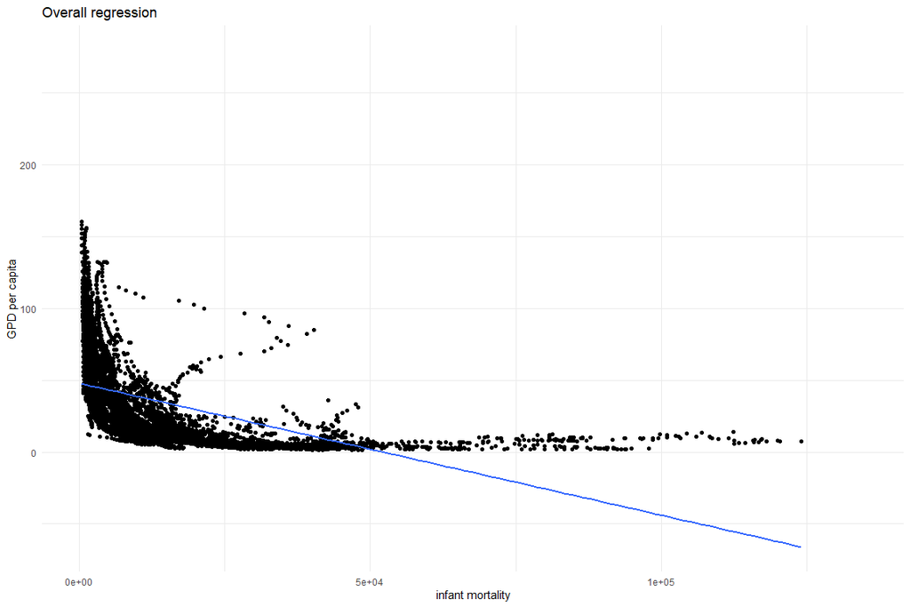

```r
ggplot(wdi, aes(x = gdpcap, y = infmort), na.rm = TRUE) +
  geom_point() +
  labs(title = 'Overall regression',
       x = 'infant mortality',
       y = 'GPD per capita') +
  geom_smooth(method = "lm", se = FALSE) +
  theme_minimal()
```

According to the overall linear regression model, GPD per capita is negatively associated with infant mortality. To be more specific, one unit increase in GPD per capita is associated with 9.188e-04 unite decrease in infant mortality on average. This association is significant on the level of 0.001 (SE = 1.977e-05, P < 2e-16).

However, as the plot suggest, while the association between GPD per capita and infant mortality is negative, it might not be a good idea to assume that the association is linear. As the plot below indicates, this association is more like a non-linear one, which certainly deserve further investigation.

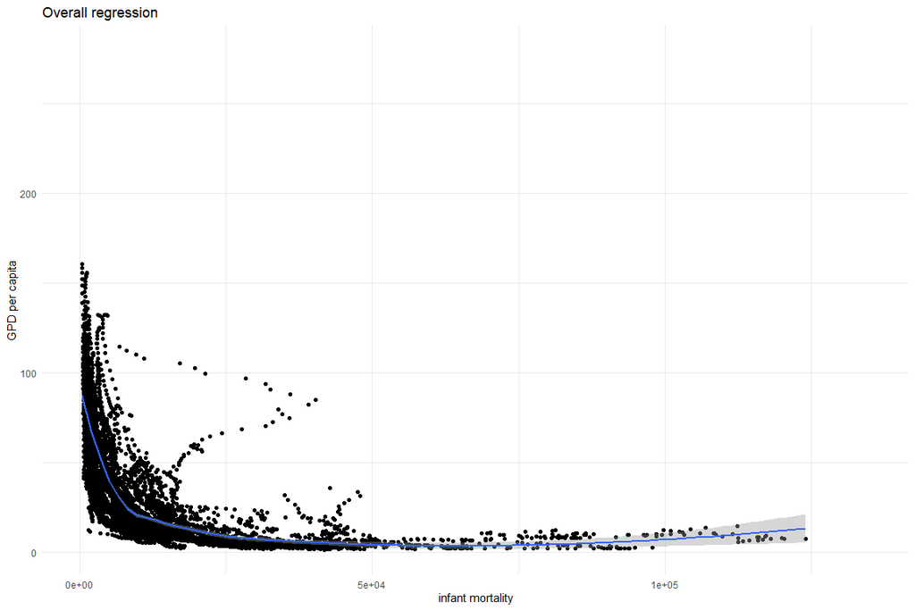

```r
ggplot(wdi, aes(x = gdpcap, y = infmort), na.rm = TRUE) +
  geom_point() +
  labs(title = 'Overall regression',
       x = 'infant mortality',
       y = 'GPD per capita') +
  geom_smooth(method = "loess", se = TRUE) +
  theme_minimal()
```

#### c) Regression by region

Let’s see if the overall relationship holds within world regions. Split the the data by `region` and create a nested list that contains these split data frames. In a single pipeline, re-estimate the regression for each of these data frames, obtain the coefficient estimates for the slope for each region and present them in a table (sorted by size of the coefficient).

```r
wdi_region <- split(wdi, f = wdi$region, drop = TRUE)

wdi %>%
    split(wdi$region, drop = TRUE) %>%
    map(~ lm(infmort ~ gdpcap, data = .)) %>%
    map(~ coef(.)) %>%
    map_dbl("gdpcap") %>%
    sort() %>%
    kable() %>%
    kable_styling(bootstrap_options = "striped")
```

|  | x |
| --- | --- |
| South Asia | -0.0057679 |
| Sub-Saharan Africa | -0.0022603 |
| Latin America & Caribbean | -0.0011522 |
| East Asia & Pacific | -0.0005843 |
| Europe & Central Asia | -0.0004898 |
| Middle East & North Africa | -0.0002757 |
| North America | -0.0000147 |

#### d) Regression by country

Let’s also check if the relationship is consistent if estimated within countries. Split the overall data by `country` and create a nested list that contains these split data frames.

Again, estimate a simple linear regression, predicting infant mortality by GDP per capita. In what percentage of the within-country regressions do we find a positive relationship (at the 95% confidence level) between GDP per capita and infant mortality? Make a histogram of the slope coefficients to illustrate the variation of the estimated relationship. Which country cases are most at odds with the overall regression estimated in part (b)?

*Note:* For some countries, there is probably insufficient or no data to estimate the model. I suggest using one of the functions dealing with error (`safely` / `possibly`) to make sure you obtain the results for the other country regressions. Alternatively, you can remove countries with insufficient data before the regressions.

```r
wdi_country <- split(wdi, f = wdi$country, drop = TRUE)

country_m <- wdi %>% split(wdi$country, drop = TRUE) %>%
                     map(possibly(~ lm(infmort ~ gdpcap, data = .), NA))


country_df <- as.data.frame(names(country_m))
names(country_df) <- c('name')

country_df$coef_gdpcap <- country_m %>% map('coefficients') %>%
                                        map('gdpcap')

country_df$p_gdpcap <- country_m  %>% map(summary) %>%
                                      map('coefficients') %>%
                                      map(8)

country_df <- country_df %>% drop_na() %>%
                             mutate(pos = (coef_gdpcap>0 & p_gdpcap<0.05),
                                    coef_gdpcap = as.numeric(coef_gdpcap),
                                    p_gdpcap = as.numeric(p_gdpcap))

#percentage of positive relationship
percentage <- round(sum(country_df$pos)/length(country_df$pos)*100,2)
```

We can find a positive relationship (at the 95% confidence level) between GDP per capita and infant mortality in about 4.86% of the within-country regressions.

Below is a histgram of the slope coefficients. From the plot, we know that in most countries the coefficient is around 0, while in several ‘outlier’ countries, the coefficient is about -0.2 or over 0.1.

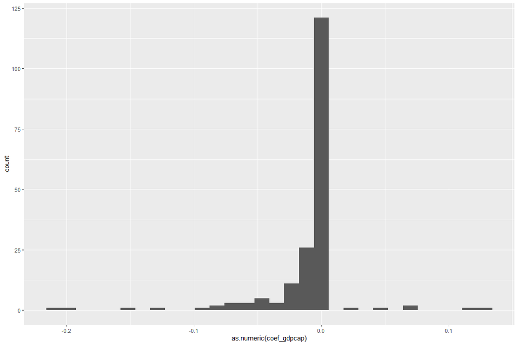

```r
ggplot(data = country_df, aes(as.numeric(coef_gdpcap))) +
  geom_histogram()
```

```r
m1 <- lm(wdi$infmort ~ wdi$gdpcap)
summary(m1)
```

```
##
## Call:
## lm(formula = wdi$infmort ~ wdi$gdpcap)
##
## Residuals:
##    Min     1Q Median     3Q    Max
## -34.68 -19.43  -8.70  12.47 112.99
##
## Coefficients:
##               Estimate Std. Error t value Pr(>|t|)
## (Intercept)  4.796e+01  4.717e-01  101.68   <2e-16 ***
## wdi$gdpcap  -9.188e-04  1.977e-05  -46.46   <2e-16 ***
## ---
## Signif. codes:  0 '***' 0.001 '**' 0.01 '*' 0.05 '.' 0.1 ' ' 1
##
## Residual standard error: 26.05 on 5165 degrees of freedom
##   (7518 observations deleted due to missingness)
## Multiple R-squared:  0.2948, Adjusted R-squared:  0.2946
## F-statistic:  2159 on 1 and 5165 DF,  p-value: < 2.2e-16
```

```r
coef_overall <- m1$coefficients[2]
```

From 2(b) we know that the coefficient of gdpcap is -0.00092 in the overall regression. As the table below indicates, country **Malawi** has most different slope coefficients from the overall regression.

```r
country_df %>% mutate(diff = abs(as.numeric(coef_gdpcap) - coef_overall)) %>%
               top_n(1, diff) %>%
               select(name, 'coefficient' = coef_gdpcap, 'p-value' = p_gdpcap, 'difficience' = diff) %>%
               kable() %>%
               kable_styling(bootstrap_options = "striped")
```

| name | coefficient | p-value | difficience |
| --- | --- | --- | --- |
| Malawi | -0.2111579 | 0 | 0.2102392 |

#### e) Added squared term

Let’s see if we can improve the models slightly. Using the list of country data frames from (d), estimate regressions of infant mortality on GDP per capita and the square of GDP per capita. Compare the adjusted R-Squareds of the models with and without the added squared term of GDP per capita. Provide the average model adjusted R-squared with and without the squared term. Would you recommend to keep the squared term or not?

```r
country_m1 <- wdi %>% split(wdi$country, drop = TRUE) %>%
                      map(possibly(~ lm(infmort ~ gdpcap, data = .), NA))
country_m2 <- wdi %>% split(wdi$country, drop = TRUE) %>%
                      map(possibly(~ lm(infmort ~ gdpcap + I(gdpcap^2), data = .), NA))

df_compare <- as.data.frame(names(country_m1))
names(df_compare) <- c('name')

df_compare$coef_gdpcap1 <- country_m1 %>% map(summary) %>%
                                          map('adj.r.squared')
df_compare$coef_gdpcap2 <- country_m2 %>% map(summary) %>%
                                          map('adj.r.squared')

df_compare %>% drop_na() %>%
               mutate(coef_gdpcap1 = as.numeric(coef_gdpcap1),
                      coef_gdpcap2 = as.numeric(coef_gdpcap2)) %>%
               summarise('without squared term of GDP per capita' = mean(coef_gdpcap1),
                         'with squared term of GDP per capita' = mean(coef_gdpcap2)) %>%
               kable(caption = 'adjusted R-Squareds') %>%
               kable_styling(bootstrap_options = "striped")
```

adjusted R-Squareds

| without squared term of GDP per capita | with squared term of GDP per capita |
| --- | --- |
| 0.6619114 | 0.7516651 |

As the table above indicates, the average adjusted R-Squareds of the model with squared term of GDP per capita is higher than the one without the squared term. Therefore, I would recommend to keep the squared term.